# Water wakes you up! The water avalibility effect in Acacia rubida and Acacia baileyana seed germination

Wang YueDuo Sdu202000700268

2022-05-15

## Our research question is:

Does water availability affect germination of A. baileyana and A. rubida seeds? If yes, in what way? Can we prove that in arid conditions seeds of A. baileyana germinate more readily than seeds of A. rubida?

## Part 1: Loading the data:

Before read the data, all the data files were imported as .csv format. Now read the data:

Read data.csv:

```r
data <- read.csv("data.csv", stringsAsFactors = T)
data
```

```
##    sample total_3 total_5 total_7 total_10 total_12 total_14
## 1  XAS1R1       2       2       2        3        3        3
## 2  XAS1R2       0       0       1        1        1        2
## 3  XAS2R1       2       2       2        4        4        4
## 4  XAS2R2       2       3       4        4        4        4
## 5  XAS3R1       3       3       4        4        4        4
## 6  XAS3R2       1       3       3        4        4        4
## 7  XAS4R1       2       2       2        2        2        2
## 8  XAS4R2       4       4       4        5        5        5
## 9  XBS1R1       1       1       2        2        3        3
## 10 XBS1R2       0       1       1        1        1        1
## 11 XBS2R1       2       2       2        4        4        4
## 12 XBS2R2       1       3       3        3        4        4
## 13 XBS3R1       3       3       4        4        4        4
## 14 XBS3R2       1       3       3        4        4        4
```

[output cut: 34 more lines]

Read samples.csv:

```r
samples <- read.csv("samples.csv", stringsAsFactors = T)
samples
```

```
##    sample   species pressure shelf
## 1  XAS1R1    rubida      0.0    S1
## 2  XAS1R2    rubida      0.0    S1
## 3  XAS2R1    rubida      0.0    S2
## 4  XAS2R2    rubida      0.0    S2
## 5  XAS3R1    rubida      0.0    S3
## 6  XAS3R2    rubida      0.0    S3
## 7  XAS4R1    rubida      0.0    S4
## 8  XAS4R2    rubida      0.0    S4
## 9  XBS1R1    rubida     -0.5    S1
## 10 XBS1R2    rubida     -0.5    S1
## 11 XBS2R1    rubida     -0.5    S2
## 12 XBS2R2    rubida     -0.5    S2
## 13 XBS3R1    rubida     -0.5    S3
## 14 XBS3R2    rubida     -0.5    S3
```

[output cut: 34 more lines]

```r
str(samples)
```

```
## 'data.frame':    48 obs. of  4 variables:
##  $ sample  : Factor w/ 48 levels "XAS1R1","XAS1R2",..: 1 2 3 4 5 6 7 8 9 10 ...
##  $ species : Factor w/ 2 levels "baileyana","rubida": 2 2 2 2 2 2 2 2 2 2 ...
##  $ pressure: num  0 0 0 0 0 0 0 0 -0.5 -0.5 ...
##  $ shelf   : Factor w/ 4 levels "S1","S2","S3",..: 1 1 2 2 3 3 4 4 1 1 ...
```

As RStudio cannot use numerical data as factors, so column should be converted into factor data type, and also rearrange the factor levels:

```r
samples$pressure <- factor(samples$pressure, c("0", "-0.5", "-1"))
str(samples)
```

```
## 'data.frame':    48 obs. of  4 variables:
##  $ sample  : Factor w/ 48 levels "XAS1R1","XAS1R2",..: 1 2 3 4 5 6 7 8 9 10 ...
##  $ species : Factor w/ 2 levels "baileyana","rubida": 2 2 2 2 2 2 2 2 2 2 ...
##  $ pressure: Factor w/ 3 levels "0","-0.5","-1": 1 1 1 1 1 1 1 1 2 2 ...
##  $ shelf   : Factor w/ 4 levels "S1","S2","S3",..: 1 1 2 2 3 3 4 4 1 1 ...
```

Merge them together and assign to variable:

```r
seeds <- merge(samples, data)
seeds
```

```
##    sample   species pressure shelf total_3 total_5 total_7 total_10 total_12
## 1  XAS1R1    rubida        0    S1       2       2       2        3        3
## 2  XAS1R2    rubida        0    S1       0       0       1        1        1
## 3  XAS2R1    rubida        0    S2       2       2       2        4        4
## 4  XAS2R2    rubida        0    S2       2       3       4        4        4
## 5  XAS3R1    rubida        0    S3       3       3       4        4        4
## 6  XAS3R2    rubida        0    S3       1       3       3        4        4
## 7  XAS4R1    rubida        0    S4       2       2       2        2        2
## 8  XAS4R2    rubida        0    S4       4       4       4        5        5
## 9  XBS1R1    rubida     -0.5    S1       1       1       2        2        3
## 10 XBS1R2    rubida     -0.5    S1       0       1       1        1        1
## 11 XBS2R1    rubida     -0.5    S2       2       2       2        4        4
## 12 XBS2R2    rubida     -0.5    S2       1       3       3        3        4
## 13 XBS3R1    rubida     -0.5    S3       3       3       4        4        4
## 14 XBS3R2    rubida     -0.5    S3       1       3       3        4        4
```

[output cut: 83 more lines]

Remove unnecessary data:

```r
rm(data, samples)
```

## Part 2: Calculate the Mean Time to Germination (MTG):

Calculation of the number of seeds germinated per interval Create 6 new columns named interval_ with the number of seeds germinated in the interval:

```r
seeds$interval_3  <- seeds$total_3
seeds$interval_5  <- seeds$total_5  - seeds$total_3
seeds$interval_7  <- seeds$total_7  - seeds$total_5
seeds$interval_10 <- seeds$total_10 - seeds$total_7
seeds$interval_12 <- seeds$total_12 - seeds$total_10
seeds$interval_14 <- seeds$total_14 - seeds$total_12

seeds
```

```
##    sample   species pressure shelf total_3 total_5 total_7 total_10 total_12
## 1  XAS1R1    rubida        0    S1       2       2       2        3        3
## 2  XAS1R2    rubida        0    S1       0       0       1        1        1
## 3  XAS2R1    rubida        0    S2       2       2       2        4        4
## 4  XAS2R2    rubida        0    S2       2       3       4        4        4
## 5  XAS3R1    rubida        0    S3       3       3       4        4        4
## 6  XAS3R2    rubida        0    S3       1       3       3        4        4
## 7  XAS4R1    rubida        0    S4       2       2       2        2        2
## 8  XAS4R2    rubida        0    S4       4       4       4        5        5
## 9  XBS1R1    rubida     -0.5    S1       1       1       2        2        3
## 10 XBS1R2    rubida     -0.5    S1       0       1       1        1        1
## 11 XBS2R1    rubida     -0.5    S2       2       2       2        4        4
## 12 XBS2R2    rubida     -0.5    S2       1       3       3        3        4
## 13 XBS3R1    rubida     -0.5    S3       3       3       4        4        4
## 14 XBS3R2    rubida     -0.5    S3       1       3       3        4        4
```

[output cut: 132 more lines]

Calculate the weighted mean using the periods in the experiment. This function will take the number of seeds germinated per period as the weights.

```r
calcMTG <- function(weights){
  weighted.mean(c(3, 5, 7, 10, 12, 14), weights)
}
```

Check that the new function generates correct results:

```r
calcMTG(c(0, 0, 0, 0, 1, 1))
```

```
## [1] 13
```

```r
calcMTG(c(1, 0, 1, 0, 0, 2))
```

```
## [1] 9.5
```

Apply this function to the rows of the data:

```r
mtg <- apply(seeds[, c("interval_3", "interval_5", "interval_7", "interval_10", "interval_12", "interval_14")], 1, calcMTG)
mtg
```

```
##  [1]  5.333333 10.500000  6.500000  4.500000  4.000000  5.750000  3.000000
##  [8]  4.400000  7.333333  5.000000  6.500000  6.250000  4.000000  5.750000
## [15]  3.000000  3.000000 12.000000 14.000000  7.000000  9.500000  9.500000
## [22] 12.000000 12.000000  7.000000  3.500000  5.250000  5.600000  6.750000
## [29]  5.200000  3.500000  6.250000  5.400000  3.666667  6.666667  4.000000
## [36]  7.500000  7.500000  5.333333  3.666667  4.600000 12.000000 11.000000
## [43] 12.666667 12.000000 11.000000  9.666667 12.000000 13.500000
```

Add the calculated MTG values as a new column

```r
seeds$MTG <- round(mtg, 2)
rm(mtg)

seeds
```

```
##    sample   species pressure shelf total_3 total_5 total_7 total_10 total_12
## 1  XAS1R1    rubida        0    S1       2       2       2        3        3
## 2  XAS1R2    rubida        0    S1       0       0       1        1        1
## 3  XAS2R1    rubida        0    S2       2       2       2        4        4
## 4  XAS2R2    rubida        0    S2       2       3       4        4        4
## 5  XAS3R1    rubida        0    S3       3       3       4        4        4
## 6  XAS3R2    rubida        0    S3       1       3       3        4        4
## 7  XAS4R1    rubida        0    S4       2       2       2        2        2
## 8  XAS4R2    rubida        0    S4       4       4       4        5        5
## 9  XBS1R1    rubida     -0.5    S1       1       1       2        2        3
## 10 XBS1R2    rubida     -0.5    S1       0       1       1        1        1
## 11 XBS2R1    rubida     -0.5    S2       2       2       2        4        4
## 12 XBS2R2    rubida     -0.5    S2       1       3       3        3        4
## 13 XBS3R1    rubida     -0.5    S3       3       3       4        4        4
## 14 XBS3R2    rubida     -0.5    S3       1       3       3        4        4
```

[output cut: 132 more lines]

## Part 3: Calculate the Germination Fraction (GF):

calculate the GF and assign it as a new column:

```r
seeds$GF <- seeds$total_14 / 5
seeds
```

```
##    sample   species pressure shelf total_3 total_5 total_7 total_10 total_12
## 1  XAS1R1    rubida        0    S1       2       2       2        3        3
## 2  XAS1R2    rubida        0    S1       0       0       1        1        1
## 3  XAS2R1    rubida        0    S2       2       2       2        4        4
## 4  XAS2R2    rubida        0    S2       2       3       4        4        4
## 5  XAS3R1    rubida        0    S3       3       3       4        4        4
## 6  XAS3R2    rubida        0    S3       1       3       3        4        4
## 7  XAS4R1    rubida        0    S4       2       2       2        2        2
## 8  XAS4R2    rubida        0    S4       4       4       4        5        5
## 9  XBS1R1    rubida     -0.5    S1       1       1       2        2        3
## 10 XBS1R2    rubida     -0.5    S1       0       1       1        1        1
## 11 XBS2R1    rubida     -0.5    S2       2       2       2        4        4
## 12 XBS2R2    rubida     -0.5    S2       1       3       3        3        4
## 13 XBS3R1    rubida     -0.5    S3       3       3       4        4        4
## 14 XBS3R2    rubida     -0.5    S3       1       3       3        4        4
```

[output cut: 132 more lines]

## Part 4: Perform ANOVA on the MTG

#### Null hypotheses:

1.Acacia Rubida and Acacia Baileyana are having different MTG due to the species factor. 2.Three water availability (pure water, -0.5 MPa and -1.0 MPa) are having different MTG due to pressure factor. 3.There exist interaction between species and pressure factor.

Perform ANOVA model:

```r
seeds.mtg.aov <- aov(MTG ~ species * pressure + shelf, data = seeds)
```

Perform ANOVA table:

```r
summary(seeds.mtg.aov)
```

```
##                  Df Sum Sq Mean Sq F value  Pr(>F)
## species           1    2.3    2.26   0.715   0.403
## pressure          2  354.6  177.30  56.033 3.4e-12 ***
## shelf             3   15.5    5.18   1.637   0.197
## species:pressure  2    5.8    2.88   0.910   0.411
## Residuals        39  123.4    3.16
## ---
## Signif. codes:  0 '***' 0.001 '**' 0.01 '*' 0.05 '.' 0.1 ' ' 1
```

Perform diagnostic plots:

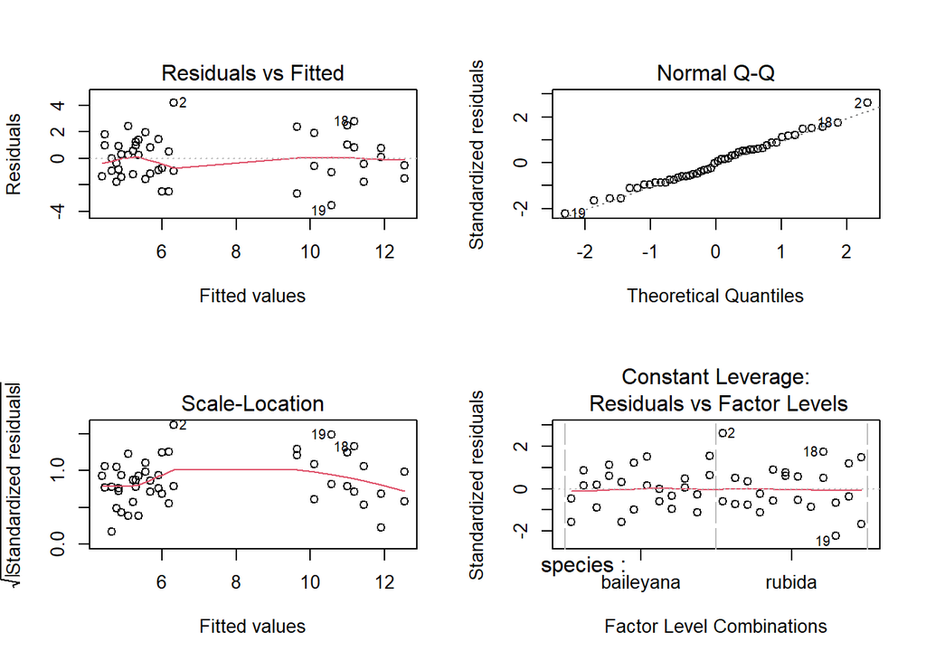

```r
par(mfrow = c(2, 2))
plot(seeds.mtg.aov)
```

```r
par(mfrow = c(1, 1))
```

Means in the groups:

```r
seeds.mtg.means <- model.tables(seeds.mtg.aov, "means")
seeds.mtg.means$tables$`species:pressure`
```

```
##            pressure
## species     0        -0.5     -1
##   baileyana  5.18125  5.36750 11.73000
##   rubida     5.49750  5.10375 10.37500
```

Perform TukeyHSD pairwise tests:

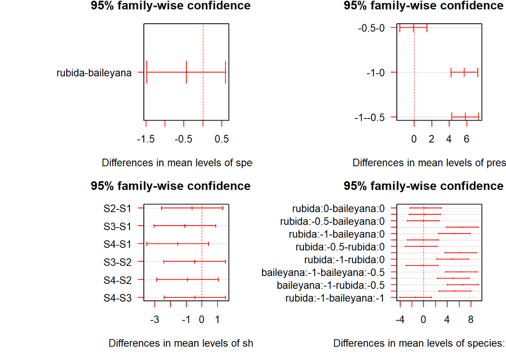

```r
seeds.mtg.hsd <- TukeyHSD(seeds.mtg.aov)

par(mar = c(5, 12, 2, 2))
par(mfrow = c(2, 2))
plot(seeds.mtg.hsd, las = 1, col = "red")
```

```r
par(mfrow = c(1, 1))
```

Perform interaction plot:

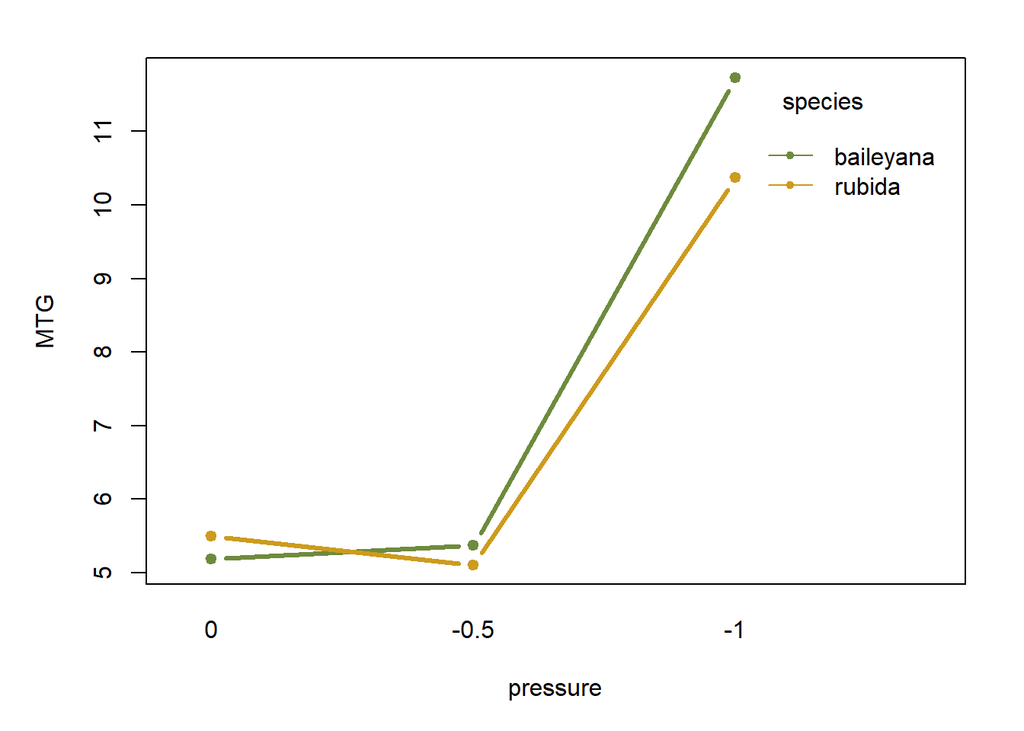

```r
par(mar = c(5, 5, 2, 2))
interaction.plot(seeds$pressure, seeds$species, seeds$MTG, col = c("darkolivegreen4", "goldenrod3"), type = "b", lty = 1, lwd = 3, pch = c(20, 20), trace.label = "species", xlab = "pressure", ylab = "MTG")
```

## Part 5：Graphical presentation of MTG

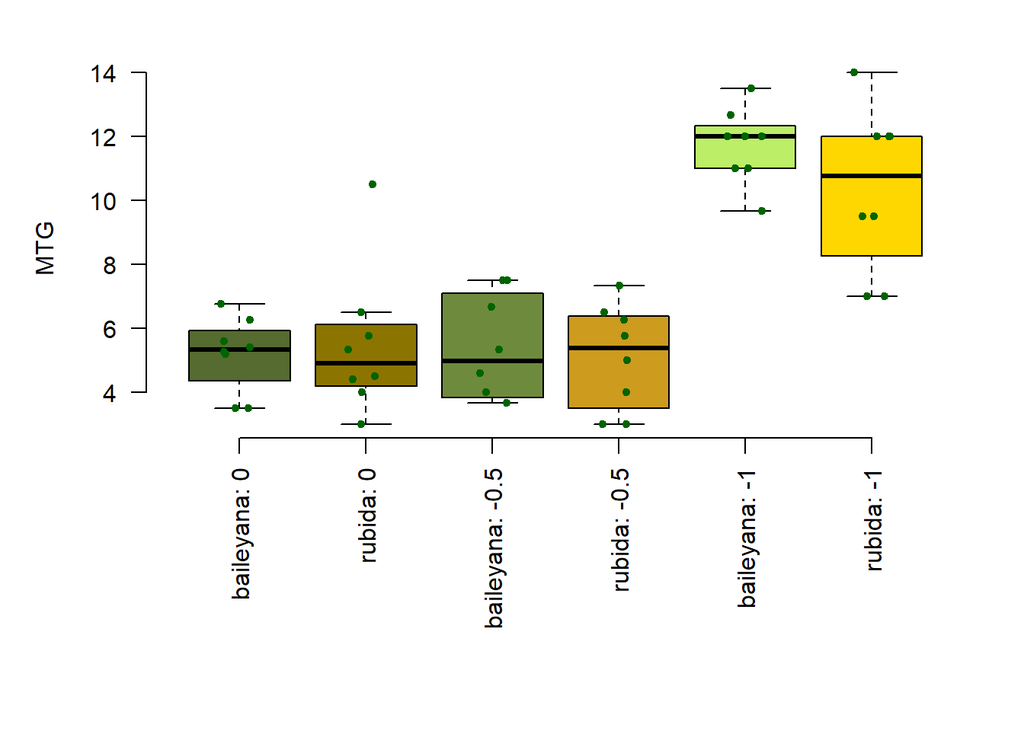

```r
par(mar = c(10, 5, 2, 2))
boxplot(MTG ~ species + pressure, data = seeds, las = 2, col = c("darkolivegreen", "gold4", "darkolivegreen4", "goldenrod3", "darkolivegreen2", "gold"), frame = F, outline = F, sep = ": ", xlab = "")
stripchart(MTG ~ species + pressure, data = seeds, vertical = T, method = "jitter", jitter = 0.15, pch = 20, col = "darkgreen", add = T)
```

The MTG of baileyana and rubida were approximately the same in every water potential.There is no obvious increase in 0 MPa and -0.5 MPa. However when the Water potential is reduced to -1.0 MPa, the MTG of both baileyana and rubida were obviously observed to be increased.

## Part 6：Perform ANOVA on the GF

#### Null hypotheses:

1.Acacia Rubida and Acacia Baileyana are having different GF due to the species factor. 2.Three water availability (pure water, -0.5 MPa and -1.0 MPa) are having different GF due to pressure factor. 3.There exist interaction between species and pressure factor.

Perform ANOVA model:

```r
seeds.mtg.aov <- aov(GF ~ species * pressure + shelf, data = seeds)
```

Perform ANOVA table:

```r
summary(seeds.mtg.aov)
```

```
##                  Df Sum Sq Mean Sq F value   Pr(>F)
## species           1 0.3008  0.3008  11.782  0.00143 **
## pressure          2 0.8600  0.4300  16.840 5.35e-06 ***
## shelf             3 0.3292  0.1097   4.297  0.01032 *
## species:pressure  2 0.1267  0.0633   2.480  0.09683 .
## Residuals        39 0.9958  0.0255
## ---
## Signif. codes:  0 '***' 0.001 '**' 0.01 '*' 0.05 '.' 0.1 ' ' 1
```

In ANOVA test on the GF, the p-value of species, pressure and species:pressure are 0.00143,5.35e-06,0.09683 respectively. Thus, “species” and “pressure” groups are having statistical significance. Only null hypotheses 1,2 can be rejected. This implies that there is no interaction between species and pressure on the GF. In addition, p-value of “shelf” is 0.01032<0.05, which means there exist statistical significance in “shelf” group.

Perform diagnostic plots:

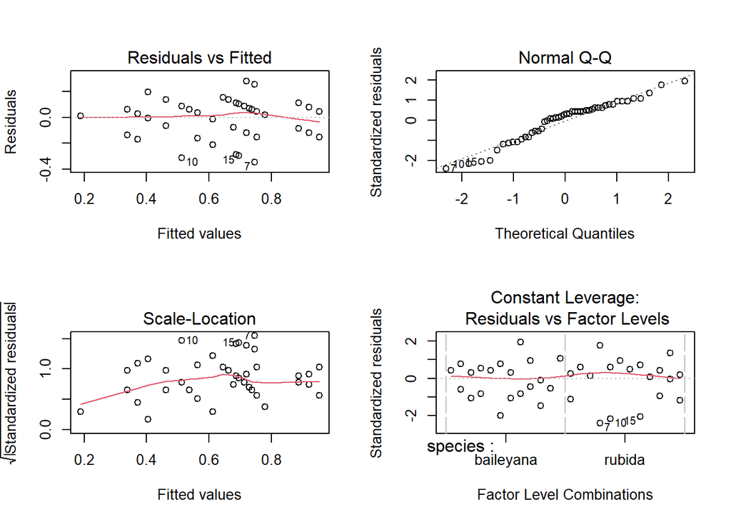

```r
par(mfrow = c(2, 2))
plot(seeds.mtg.aov)
```

```r
par(mfrow = c(1, 1))
```

Means in the groups:

```r
seeds.mtg.means <- model.tables(seeds.mtg.aov, "means")
seeds.mtg.means$tables$`species:pressure`
```

```
##            pressure
## species     0     -0.5  -1
##   baileyana 0.875 0.675 0.600
##   rubida    0.700 0.650 0.325
```

TukeyHSD pairwise tests:

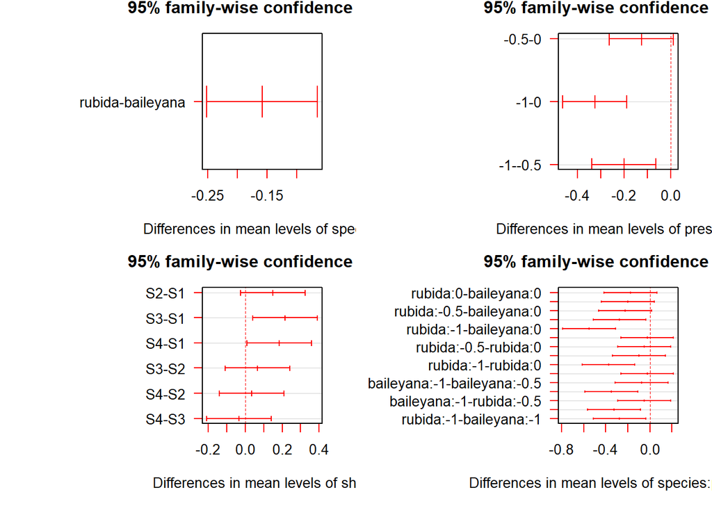

```r
seeds.mtg.hsd <- TukeyHSD(seeds.mtg.aov)

par(mar = c(5, 12, 2, 2))
par(mfrow = c(2, 2))
plot(seeds.mtg.hsd, las = 1, col = "red")
```

```r
par(mfrow = c(1, 1))
```

Interaction plot:

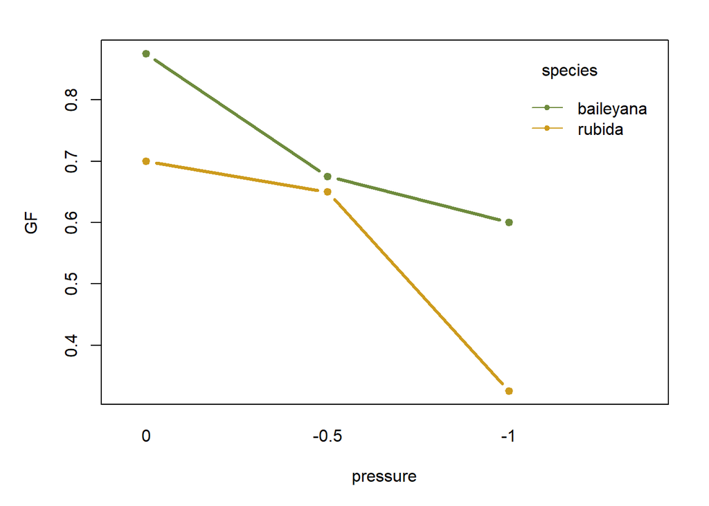

```r
par(mar = c(5, 5, 2, 2))
interaction.plot(seeds$pressure, seeds$species, seeds$GF, col = c("darkolivegreen4", "goldenrod3"), type = "b", lty = 1, lwd = 3, pch = c(20, 20), trace.label = "species", xlab = "pressure", ylab = "GF")
```

## Part 7：Graphical presentation of GF

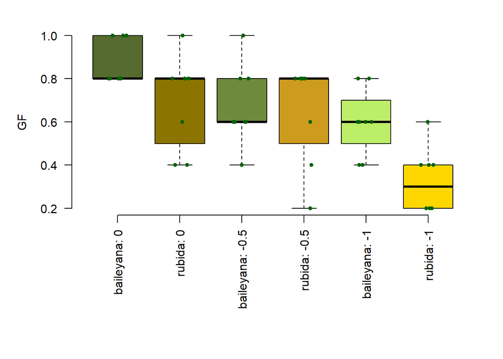

```r
par(mar = c(10, 5, 2, 2))
boxplot(GF ~ species + pressure, data = seeds, las = 2, col = c("darkolivegreen", "gold4", "darkolivegreen4", "goldenrod3", "darkolivegreen2", "gold"), frame = F, outline = F, sep = ": ", xlab = "")
stripchart(GF ~ species + pressure, data = seeds, vertical = T, method = "jitter", jitter = 0.15, pch = 20, col = "darkgreen", add = T)
```

The GF of baileyana is larger than that of rubida’s, and in lower water potential condition, GF of both baileyana and rubida were reduced.

## Part 8: Discussion and conclusion:

### Discussion:

To reveal if and how can water avalibility affects the germination of A. baileyana and A. rubida seeds and also whether seeds of A. baileyana germinate more readily than seeds of A. rubida in arid condition, 120 seeds from each A. baileyana and A. rubida respectively (240 seeds in total) and 48 culture plates were treated, with MTG and GF were calculated, and ANOVA test were used to analyse MTG and GF.

In ANOVA test on MTG, only pressure factor was found to have statistical significance. This represents that arid conditions do extended the mean time to germination in baileyana and rubida, especially when water potential is reduced to -1.0 MPa. However, the species factor was not found to have statistical significance, which means the MTG of baileyana and rubida have no relationship with species. On the other hand, the shelf where the culture plates were put do not have effect on MTG, and there were also no interaction between species and pressure.

In ANOVA test on GF, species and pressure factor were found to have statistical significance. This represents that arid conditions do lessen the germination fraction in both baileyana and rubida and the species factor was found to have statistical significance, which means the GF of baileyana and rubida have relationship with species. On the other hand, there were also no interaction between species and pressure.

As species factor only have statistical significance in ANOVA test on GF, consequently, GF is more biologically relevant than MTG, in environmental stress condition. Although the mean time to germination in Acacia Rubida and Acacia Baileyana are almost same, the germination fraction is depends on the drought resistance of plant variety itself. For this reason, GF is considered to be more biologically relevant by this research.

The research done by Cochrane et al. (2014) pointed out that increasing drought stress led to reduced and delayed germination in all species, which is consistent with the conclusion of this study [4]. However, depends on the p-value of “shelf” group in GF (p=0.01032) is less than 0.05, different shelf where culture plates were put is obversed to have an effect on GF, which is not line with the expectation that the shelf where the culture plates were put should not have effect on GF. This probably caused by the density of each component in the air is different, such as CO2 and O2. Consequently, to improve the experiment, it is essential to maintain good ventilation situation and same temperature for each shelf layer, and also more incubator in different laboratories can be considered. Owing to A. baileyana have resistance to drought stress, consequently, genome-wide identification of drought stress related gene family based on bioinformation technique might be a considerable study direction, which further reveals the specific molecule-level mechanism of drought stress resistance.

### Conclusion:

Arid conditions not only extends the mean time to germination but also lessen the germination fraction, and lower water potential lead to longer mean time to germination and less germination fraction in baileyana and rubida. Although baileyana and rubida were having same mean time to germination in same arid conditions, the germination fraction of baileyana was observed to be statistical significantly higher than rubida, which indicates that baileyana germinate more readily than seeds of A. rubida in arid condition.